# final_project_classification

```python
import pandas as pd
import numpy as np
import matplotlib.pyplot as plt
import seaborn as sns
import statsmodels.api as sm
import pylab as py
from sklearn.metrics import classification_report

from sklearn import tree
from sklearn.svm import SVC
from sklearn.model_selection import cross_val_score
from sklearn.linear_model import LogisticRegression
from sklearn.model_selection import train_test_split
from sklearn.preprocessing import StandardScaler
from sklearn.metrics import accuracy_score, confusion_matrix, precision_score, recall_score
from sklearn.tree import DecisionTreeClassifier
from sklearn.discriminant_analysis import LinearDiscriminantAnalysis, QuadraticDiscriminantAnalysis
from sklearn.neighbors import KNeighborsClassifier
from sklearn.metrics import PredictionErrorDisplay
```

```python
## Read in data
npa = pd.read_csv("C:\\Users\\jdcli\\Downloads\\NPA_HLT.csv")
npa = npa.rename(columns={"NPAs_NPA": "NPA","NPA_Lookup__Median_Sales_Price": "Median_Sales_Price"})
## Dropped columns not needed
npa = npa[["NPA", "Median_Sales_Price"]]
## Convert to numeric
npa["Median_Sales_Price"] = pd.to_numeric(npa["Median_Sales_Price"], errors="coerce")
## Drop missing values
npa = npa.dropna(subset=["Median_Sales_Price"])
## Created classification target
threshold = npa["Median_Sales_Price"].median()
npa["Affordable"] = (npa["Median_Sales_Price"] < threshold).astype(int)
npa.head()
```

|  | NPA | Median_Sales_Price | Affordable |
| --- | --- | --- | --- |
| 0 | 188 | 354750 | 0 |
| 1 | 131 | 215000 | 1 |
| 2 | 64 | 189500 | 1 |
| 3 | 326 | 522500 | 0 |
| 4 | 336 | 240000 | 1 |

```python
## Read in employment data
employment = pd.read_csv("C:\\Users\\jdcli\\Downloads\\Employment.csv")
## Removed % and converted to float
employment["Employment"] = employment["2023"].str.replace("%", "").replace("--", None).astype(float)
employment = employment[["NPA", "Employment"]]
employment.head()
```

|  | NPA | Employment |
| --- | --- | --- |
| 0 | 2 | 95.6 |
| 1 | 3 | 97.4 |
| 2 | 4 | 94.3 |
| 3 | 5 | 82.8 |
| 4 | 6 | 100.0 |

```python
## Read in population density data
pop = pd.read_csv("C:\\Users\\jdcli\\Downloads\\Population Density.csv")
## Converted to numeric
pop["Population_Density"] = pd.to_numeric(pop["2020"], errors="coerce")
pop = pop[["NPA", "Population_Density"]]
pop.head()
```

|  | NPA | Population_Density |
| --- | --- | --- |
| 0 | 2 | 5 |
| 1 | 3 | 10 |
| 2 | 4 | 4 |
| 3 | 5 | 5 |
| 4 | 6 | 4 |

```python
## Read in education data
edu = pd.read_csv("C:\\Users\\jdcli\\Downloads\\Education Level - Bachelor's Degree.csv")
edu["Bachelors"] = (edu["2023"].str.replace("%", "").replace("--", None).astype(float))
edu = edu[["NPA", "Bachelors"]]
edu.head()
```

|  | NPA | Bachelors |
| --- | --- | --- |
| 0 | 2 | 35.2 |
| 1 | 3 | 85.4 |
| 2 | 4 | 89.4 |
| 3 | 5 | 2.5 |
| 4 | 6 | 21.0 |

```python
## Read in crime data
crime = pd.read_csv("C:\\Users\\jdcli\\Downloads\\Crime - Property.csv")
crime["Crime_Property"] = pd.to_numeric(crime["2022"], errors="coerce")
crime = crime[["NPA", "Crime_Property"]]
crime.head()
```

|  | NPA | Crime_Property |
| --- | --- | --- |
| 0 | 2 | 60.0 |
| 1 | 3 | 60.0 |
| 2 | 4 | 7.0 |
| 3 | 5 | 26.0 |
| 4 | 6 | 81.0 |

```python
## Merged all the dataframes together
df = employment.merge(edu, on="NPA", how="left")
df = df.merge(pop, on="NPA", how="left")
df = df.merge(crime, on="NPA", how="left")
df = df.merge(npa, on="NPA", how="left")
final = df.copy()
final.head()
```

|  | NPA | Employment | Bachelors | Population_Density | Crime_Property | Median_Sales_Price | Affordable |
| --- | --- | --- | --- | --- | --- | --- | --- |
| 0 | 2 | 95.6 | 35.2 | 5 | 60.0 | 535000 | 0 |
| 1 | 2 | 95.6 | 35.2 | 5 | 60.0 | 323750 | 0 |
| 2 | 2 | 95.6 | 35.2 | 5 | 60.0 | 325000 | 0 |
| 3 | 2 | 95.6 | 35.2 | 5 | 60.0 | 375000 | 0 |
| 4 | 2 | 95.6 | 35.2 | 5 | 60.0 | 565000 | 0 |

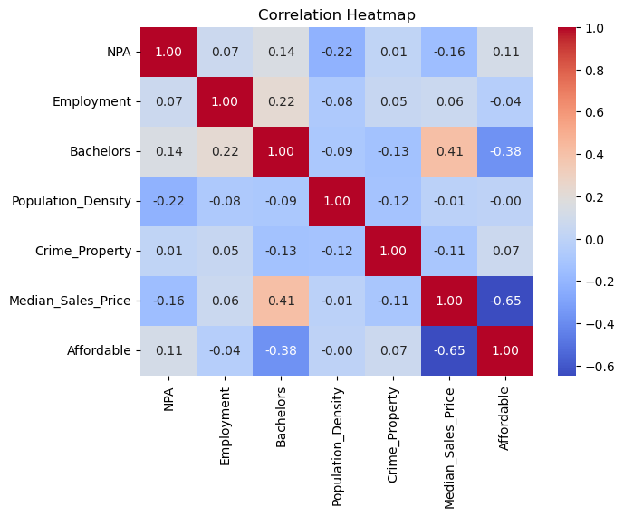

```python
##heatmap to rule out multicollinearity
plt.figure(figsize=(7, 5))
sns.heatmap(df.corr(), cmap='coolwarm', annot=True, fmt=".2f")
plt.title("Correlation Heatmap")
plt.show()
```

```python
##Cleaning data
final = final.dropna(subset=["Employment", "Bachelors", "Population_Density", "Crime_Property", "Affordable"])
##Defined features and target
X = final[["Employment", "Bachelors", "Population_Density", "Crime_Property"]]
y = final["Affordable"]

## Train and test split
X_train, X_test, y_train, y_test = train_test_split(X, y, test_size=0.3, random_state=42)

##Fit logistic regression model
model = LogisticRegression()
model.fit(X_train, y_train)
y_pred = model.predict(X_test)

##Evaluation results
print("Accuracy:", accuracy_score(y_test, y_pred))
print("Confusion Matrix:\n", confusion_matrix(y_test, y_pred))
print("Classification Report:\n", classification_report(y_test, y_pred))
```

```
Accuracy: 0.6996402877697842
Confusion Matrix:
 [[216  83]
 [ 84 173]]
Classification Report:
               precision    recall  f1-score   support

           0       0.72      0.72      0.72       299
           1       0.68      0.67      0.67       257

    accuracy                           0.70       556
   macro avg       0.70      0.70      0.70       556
weighted avg       0.70      0.70      0.70       556
```

```python
coef_df = pd.DataFrame({"Feature": X.columns,"Coefficient": model.coef_[0]})
coef_df
```

|  | Feature | Coefficient |
| --- | --- | --- |
| 0 | Employment | 0.012785 |
| 1 | Bachelors | -0.050445 |
| 2 | Population_Density | 0.038946 |
| 3 | Crime_Property | -0.001462 |

1. Higher employment rate slighlty increases the likelihood of a neighborhood being affordal as some areas with low unemplyment may not necessarily be high income.
2. String negative indicating neighborhoods with higher percent of college educated adults and more likely to be expensive.
3. Higher density may reflect that denser neighborhoods tend to be more affordable.
4. Crime has a very small negative percentage, indicating it is not a strong predictor of affordability as it implies higher crime rates equal likely to be more expensive

```python
##KNN model
knn = KNeighborsClassifier(n_neighbors=5)
knn.fit(X_train, y_train)
knn_pred = knn.predict(X_test)

print("KNN Accuracy:", accuracy_score(y_test, knn_pred))
print("KNN Confusion Matrix:\n", confusion_matrix(y_test, knn_pred))
print("KNN Classification Report:\n", classification_report(y_test, knn_pred))
```

```
KNN Accuracy: 0.6888489208633094
KNN Confusion Matrix:
 [[201  98]
 [ 75 182]]
KNN Classification Report:
               precision    recall  f1-score   support

           0       0.73      0.67      0.70       299
           1       0.65      0.71      0.68       257

    accuracy                           0.69       556
   macro avg       0.69      0.69      0.69       556
weighted avg       0.69      0.69      0.69       556
```

```python
##Decision Tree model
dt = DecisionTreeClassifier(max_depth=4, random_state=42)
dt.fit(X_train, y_train)
dt_pred = dt.predict(X_test)

print("Decision Tree Accuracy:", accuracy_score(y_test, dt_pred))
print("Decision Tree Confusion Matrix:\n", confusion_matrix(y_test, dt_pred))
print("Decision Tree Classification Report:\n", classification_report(y_test, dt_pred))
```

```
Decision Tree Accuracy: 0.7230215827338129
Decision Tree Confusion Matrix:
 [[187 112]
 [ 42 215]]
Decision Tree Classification Report:
               precision    recall  f1-score   support

           0       0.82      0.63      0.71       299
           1       0.66      0.84      0.74       257

    accuracy                           0.72       556
   macro avg       0.74      0.73      0.72       556
weighted avg       0.74      0.72      0.72       556
```

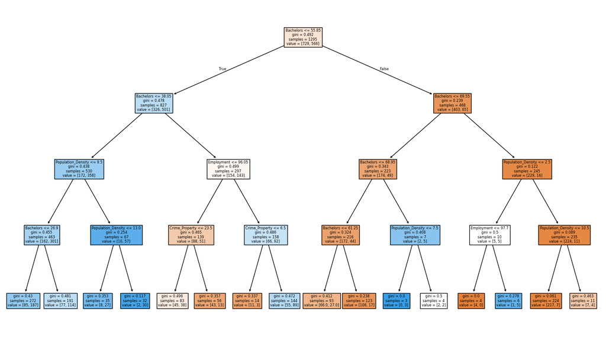

```python
fig = plt.figure(figsize=(25,20))
tree.plot_tree(dt, feature_names=['Employment', 'Bachelors', 'Population_Density', 'Crime_Property'], filled=True)
fig = plt.gcf()
fig.set_size_inches(18, 10)
```

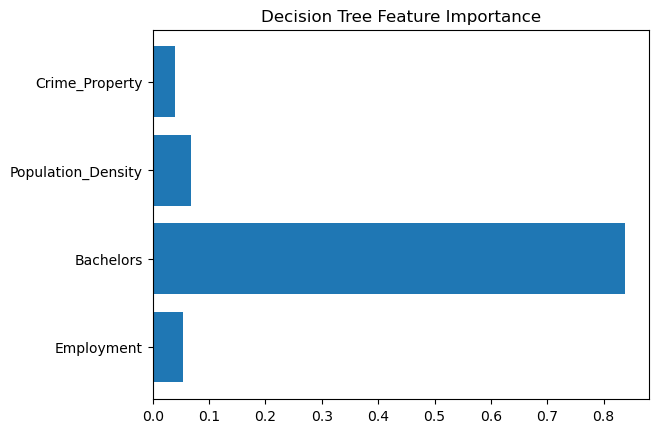

```python
##Feature importance from decision tree
importances = dt.feature_importances_
plt.barh(X.columns, importances)
plt.title("Decision Tree Feature Importance")
plt.show()
```

Feature importance of Decision Tree model as it produced the highest accuracy. Bachelors is clearly showed to have the most influence impact on price.

```python
##LDA model
lda = LinearDiscriminantAnalysis()
lda.fit(X_train, y_train)
lda_pred = lda.predict(X_test)
print("LDA Accuracy:", accuracy_score(y_test, lda_pred))
print("LDA Confusion Matrix:\n", confusion_matrix(y_test, lda_pred))
print("LDA Classification Report:\n", classification_report(y_test, lda_pred))
```

```
LDA Accuracy: 0.7050359712230215
LDA Confusion Matrix:
 [[216  83]
 [ 81 176]]
LDA Classification Report:
               precision    recall  f1-score   support

           0       0.73      0.72      0.72       299
           1       0.68      0.68      0.68       257

    accuracy                           0.71       556
   macro avg       0.70      0.70      0.70       556
weighted avg       0.71      0.71      0.71       556
```

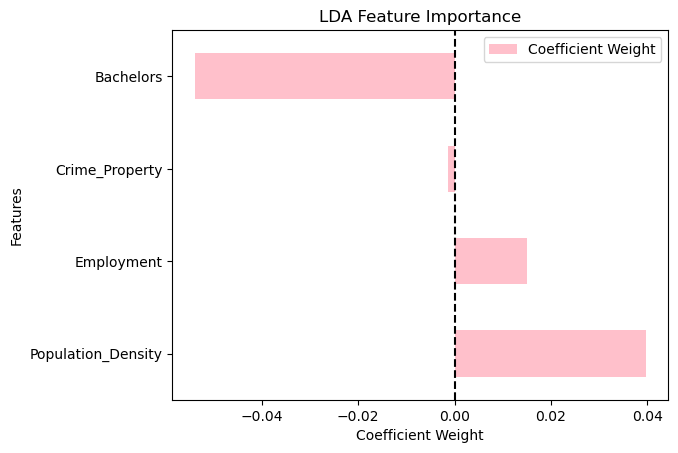

```python
## feature importance for LDA coefficients
coef_df = pd.DataFrame(lda.coef_, columns=X_train.columns).transpose()
coef_df.columns = ['Coefficient Weight']
coef_df = coef_df.sort_values(by='Coefficient Weight', ascending=False)

coef_df.plot(kind='barh', color='pink')
plt.title("LDA Feature Importance")
plt.axvline(color='black', linestyle='--')
plt.xlabel("Coefficient Weight")
plt.ylabel("Features")
plt.show()
```

Feature importance for LDA as produced the better of the confusion matrixes. This shows which features contributes to each seperted class clearly showing Bachelor's as the most influential.

```python
##QDA model
qda = QuadraticDiscriminantAnalysis()
qda.fit(X_train, y_train)
qda_pred = qda.predict(X_test)

print("QDA Accuracy:", accuracy_score(y_test, qda_pred))
print("QDA Confusion Matrix:\n", confusion_matrix(y_test, qda_pred))
print("QDA Classification Report:\n", classification_report(y_test, qda_pred))
```

```
QDA Accuracy: 0.6888489208633094
QDA Confusion Matrix:
 [[192 107]
 [ 66 191]]
QDA Classification Report:
               precision    recall  f1-score   support

           0       0.74      0.64      0.69       299
           1       0.64      0.74      0.69       257

    accuracy                           0.69       556
   macro avg       0.69      0.69      0.69       556
weighted avg       0.70      0.69      0.69       556
```

Overall, the classification models performed solidly for using neighborhood level factors to predict whether an area is affordable or expensive. All accuracy score were within the margin of 0.69 - 0.72 indicating the models performed well. The Decision Tree produced the best accuracy with 0.72.